# 06. 회귀분석과 공분산분석

### 회귀선의 유의성 검정

- 두 변수 사이의 회귀관계가 없다면, 반응변수의 값은 회귀변수의 값의 변동 여하에 전혀 영향을 받지 않음

  $\rightarrow$ 모형축소

  $$y = \beta_0 + \epsilon$$과 같이 쓸 수 있으며, $\beta_0$의 추정량 $b_0=\bar{y}$가 됨

  **즉, 회귀관계가 없다면, 설명변수 $x$의 값에 관계없이 반응변수 $y$값의 예측치는 $\bar{y}$가 되고, 자료평균에 의해서 설명할 수 없는 부분인 총 편차는 $y-\bar{y}$가 됨**

  총편차를 회귀선에 의해 설명할 수 있는 부분과 설명할 수 없는 부분으로 분해

  $$y-\bar{y} = (y-\hat{y})+(\hat{y}-\bar{y})$$

  $$(실제값과\;평균의\;차이) = (실제값과\;적합된\;값의\;차이)+(적합된\;값과\;평균의\;차이)$$

  **회귀선이 자료에 잘 적합되려면 $(실제값과\;평균의\;차이)$는 $(적합된\;값과\;평균의\;차이)$로 나타나야 하며, 제곱합의 분할형태로 귀착되어야 함**

  $$\sum^n_i (y_i - \bar{y})^2 = \sum^n_i [(y_i -\hat{y})+(\hat{y}-\bar{y})]^2 = \sum^n(y_i-\hat{y})^2 + \sum^n_i (\hat{y}-\bar{y})^2$$

  $$\leftrightarrow SS_T=SS_E + SS_R \;=\;S_{yy}=[b_1 S_{xy}(=b^2_1 S_{xx})] + [S_{yy}-b_1S_{xy}]$$

  $$\leftrightarrow 총제곱합=잔차제곱합 + 회귀제곱합$$

#### **자유도는**

  $$n-1=(n-2)+1$$

  $$\phi_T = \phi_E + \phi_R$$
- **총제곱합 $SS_T$ : (실제값과 평균의 차이)에 대한 제곱합으로, 관측이 평균에서 얼마나 벗어나 있는지를 평가하는 측도 $\rightarrow$ 총변동**
- **회귀제곱합 $SS_R$ : (적합된 값과 평균의 차이)에 대한 제곱합, 총변동 중 회귀선으로 설명할 수 있는 부분**

  따라서

  $$결정계수\;R^2={{SS_R}\over{SS_T}}={{회귀변동}\over{총변동}}$$이며, 0과 1사이의 값을 가지며, 두 변수 사이의 피어슨 상관계수의 제곱

  **회귀선이 자료에 잘 적합된다 함은 결정계수의 값이 큼을 의미 (= 피어슨 상관계수의 절대값이 크다는 것)**

#### 가설설정

- $H_0 : 회귀관계가\;없다$ vs $H_1 : 회귀관계가\;있다$

  $H_0 : \beta_1 = 0$ vs $H_1 : \beta_1 \neq 0$

  **귀무가설을 기각해야 회귀분석이 의미가 있음**

#### 회귀의 유의성 검정은 평균제곱 (MS)를 기초

  > **회귀계수의 유의성 검정**

  > $H_0 : \beta_1 = 0$ $H_1 : \beta_1 \neq 0$

  > 검정통계량 $F_0 = {{SS_R / 1}\over{SS_E/(n-2)}} = {{MS_R}\over{MS_E}}$

  > **만일 $F_0>F(1, n-2;\;\;\alpha)이면\;귀무가설을\;기각$**

#### 분산분석표

- $E(MS_E)=\sigma^2$로서, $MS_E$는 오차분산 $\sigma^2$의 불편추정량 $(\hat{\sigma^2}=MS_E)$

| 변인 | $제곱합$ | 자유도 | 평균제곱 | $E(MS)$ | $F_0$ |
| --- | --- | --- | --- | --- | --- |
| 회귀 | $SS_R=b_1 S_{xy}$ | 1 | $MS_R$ | $\sigma^2 + \beta_1 S_{xx}$ | $MS_R$/$MS_E$ |
| 오차 | $SS_E=S_{yy}-b_1 S_x$ | n-2 | $MS_E$ | $\sigma^2$ |  |
| 총 | $SS_T=S_{yy}$ | n-1 |  |  |  |

- 분산분석표

```r
anova(lm.out)
```

A anova: 2 × 5

|  | Df <int> | Sum Sq <dbl> | Mean Sq <dbl> | F value <dbl> | Pr(>F) <dbl> |
| --- | --- | --- | --- | --- | --- |
| x | 1 | 119.275245 | 119.2752448 | 141.1304 | 3.211246e-07 |
| Residuals | 10 | 8.451422 | 0.8451422 | NA | NA |

- $R^2=0.934$

```r
119.275245 / (8.451422+119.275245)
```

0.933831969482144

- $F_0=141.1304>F(1, 10;\;0.01)$

```r
119.2752448 / ((8.451422)/10)
```

141.130385868792

```r
qf(p = 0.01, df1 = 1, df2 = 10, lower.tail = F)
```

10.0442892733966

- 회귀계수 $\beta_1$의 95% 신뢰구간

```r
confint(lm.out, level=0.95)
```

A matrix: 2 × 2 of type dbl

|  | 2.5 % | 97.5 % |
| --- | --- | --- |
| (Intercept) | -3.009365 | 2.4308107 |
| x | 0.370997 | 0.5422898 |

### 다중선형회귀분석

- 반응변수에 영향을 미치는 설명변수가 $k$개일 때

  $$y = \beta_0 + \beta_1 x_1 + \beta_2 x_2 + \dots \beta_k x_k + \epsilon,\;\;\;\epsilon \sim N(0, \sigma^2)$$

  **$n \geq k+1$을 만족하여야 함**

## 06.02. 공분산분석 (analysis of covariance)

- 분산분석과 회귀분석이 결합된 형태
- 블록화 계획을 일반화시킨 모형으로,

  블록요인에 해당되는 계량적인 변수인 공변수(covariance)라 부르는 연속변수를 분산분석 모형에 추가하여

  오차를 줄이면서 분석의 정밀도를 높임

#### 섬유제품 강도 예시

- 각 기계로부터 생산된 섬유제품의 강도를 구해 그 차이($A$)로 기계의 효과를 파악
- 섬유제품의 강도는 기계뿐만이 아닌 원사의 두께에도 영향을 받을 때
  - 만약 원사의 두께를 '얇음'과 '두꺼움' 2가지 범주로 나눈 경우 $\rightarrow$ **이원배치**
  - 만약 원사의 두께를 정량적으로 mm단위로 측정 $\rightarrow$ **공변수**
  - **첫 번째 기계와 두 번째 기계로부터 나온 데이터에 대해 단순선형회귀를 적합**

### 공분산분석 기초

- **일원배치법 모형에 공변수가 하나 추가됨**
- $y_{ij}$ : 관심요인 $A$의 $i$번째 수준에서 $j$번째 관측된 반응값
- $\mu'$ : 총평균
- $\alpha_i$ : $A$의 $i$번째 수준의 효과
- $x_{ij}$ : $y_{ij}$에 대응되는 공변수의 값
- $\beta$ : 공변수로 반응변수를 설명하는 회귀계수

$$y_{ij} = \mu' + \alpha_i + \beta x_{ij} + \epsilon_{ij},\;\;\;\epsilon_{ij} \sim N(0, \sigma^2) = \mu + \alpha_i + \beta(x_{ij}-\bar{\bar{x}})+\epsilon_{ij}$$$$(i=1, 2, \dots, a;\;\;\;j=1, 2, \dots, n)$$

- 위의 모형에서 $\alpha_i$항이 빠지면, 공분산분석은 단순선형회귀와 같음

#### 공분산분석은 분산분석과 회귀분석이 결합된 것

### 가설설정

- $H_0 :\alpha_i = \alpha_2= \dots = \alpha_a = 0$ vs $H_1:not\;H_0$

### 제곱합 및 자유도 분할

$$\mu + \alpha_i + \beta(x_{ij}-\bar{\bar{x}})+\epsilon_{ij}$$

에서

$$S_{yy} = \sum^a_i \sum^n_j (y_{ij}-\bar{\bar{y}})^2$$$$S_{xx} = \sum^a_i \sum^n_j (x_{ij}-\bar{\bar{x}})^2$$$$S_{xy} = \sum^a_i \sum^n_j (x_{ij}-\bar{\bar{x}})(y_{ij}-\bar{\bar{y}})$$
$$T_{yy} = \sum^a_i (\bar{y}_{i.}-\bar{\bar{y}})^2$$$$T_{xx} = \sum^a_i (\bar{x}_{i.}-\bar{\bar{x}})^2$$$$T_{xy} = \sum^a_i (\bar{x}_{i.}-\bar{\bar{x}})(\bar{y}_{i.}-\bar{\bar{y}})$$
$$E_{yy} = S_{yy}-T_{yy}$$$$E_{xx} = S_{xx}-T_{xx}$$$$E_{xy} = S_{xy}-T_{xy}$$

$$S = T + E가 성립$$

#### 각 모수들의 최소제곱 추정량

$$\hat{\mu}=\bar{y}$$$$\hat{\alpha_i}=(\bar{y_{i.}}-\bar{\bar{y}})-\hat{\beta}(\bar{x_{i.}}-\bar{\bar{x}})$$$$\hat{\beta} = {{E_{xy}}\over{E_{xx}}}$$

#### 오차제곱합과 자유도

$$SS_E = E_{yy}- {{(E_{xy})^2}\over{E_{xx}}},\;\;\;\phi_E = a(n-1)-1$$$$\hat{\sigma^2}=MS_E = {{SS_E}\over{a(n-1)-1}}$$

- 만약 귀무가설이 옳다면 ($\alpha_i = 0$), 모형은 다음곽 같이 축소

  $$y_{ij}=\mu + \beta(x_{ij}-\bar{\bar{x}})+\epsilon_{ij}$$

  $$\downarrow$$

  $$\mu = \bar{\bar{y}}$$

  $$\hat{\beta} = {{S_{xy}}\over{S_{xx}}}$$

  $$\downarrow$$

  $$SS_{E'}=S_{yy}- {{(S_{xy})^2}\over{S_{xx}}},\;\;\;\phi_{E'}=an-2$$**로서, 항상 $SS_E$가 $SS_{E'}$보다 작은 값을 가지게 됨**

  **이 차이가 순수한 $\alpha_i$의 설명력에 해당**

#### 공분산분석에서의 가설검정

  > $H_0:\alpha_{1} = \dots, \alpha_{a} =0$

  > $H_1 : not\;H_0$

  > $검정통계량\;=\;F_0 ={{(SS_{E'}-SS_E)/(a-1)}\over{MS_E}}$

  > **$F_0 > F(a-1, a(n-1)-1;\;\;\;\alpha)$이면, 귀무가설을 기각**

#### 섬유제품 예시

```r
du <- c(20, 25, 24, 25, 32, 22, 28, 22, 30, 28, 21, 23, 26, 21, 15)
gang <- c(36, 41, 39, 42, 49, 40, 48, 39, 45, 44, 35, 37, 42, 34, 32)
machine <- rep(c("1", "2", "3"), c(5, 5, 5))
textile.data <- tibble(du, gang, machine)
```

- 기계 간 강도에 차이가 존재하는 것으로 추정

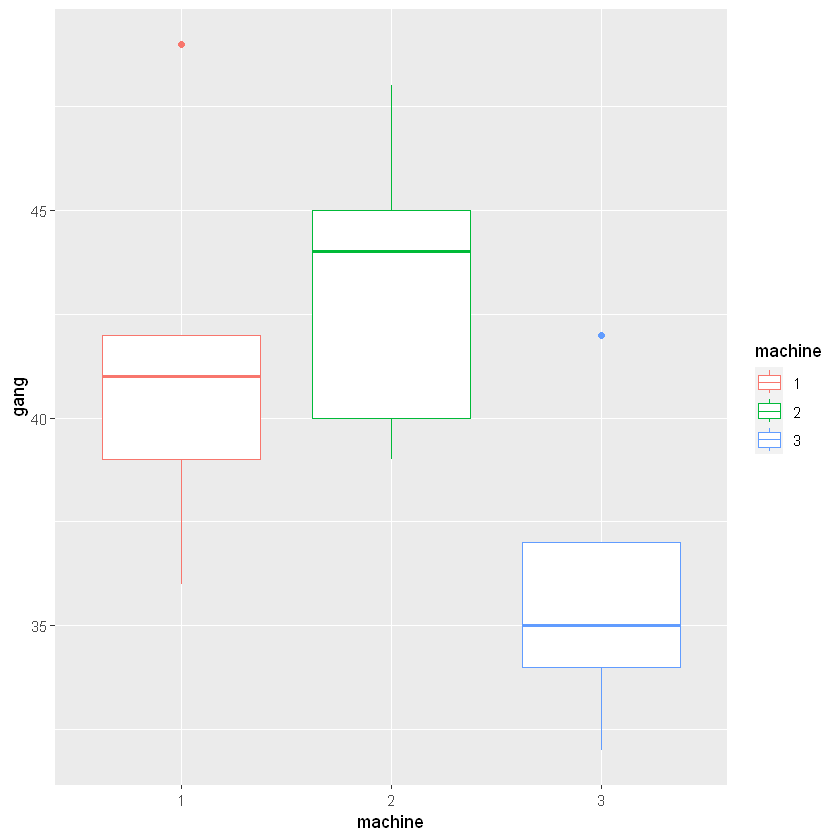

```r
textile.data %>% ggplot() + geom_boxplot(aes(machine, gang, color = machine))
```

- **`du`의 영향력을 가정하지 않은 모형 : `machine`의 효과가 유의**

```r
a1 <- aov(gang ~ machine)
tidy(a1)
```

A tibble: 2 × 6

| term <chr> | df <dbl> | sumsq <dbl> | meansq <dbl> | statistic <dbl> | p.value <dbl> |
| --- | --- | --- | --- | --- | --- |
| machine | 2 | 140.4 | 70.20000 | 4.08932 | 0.04423194 |
| Residuals | 12 | 206.0 | 17.16667 | NA | NA |

- **`du`의 영향력을 가정한 모형** :
  - $SS_{E'}=13.28353+27.98589=41.27 (df=13),\;\;\;SS_E=27.99 (df=11),\;\;\;MS_E=2.55$

    $F_0 = 2.61 < F(2, 11;\;\;0.1)=2.86$
  - **`du`의 영향력을 감안하면 `machine` 효과는 유의하지 않음**

```r
a2 <- aov(gang ~ du + machine, textile.data)
tidy(a2)
```

A tibble: 3 × 6

| term <chr> | df <dbl> | sumsq <dbl> | meansq <dbl> | statistic <dbl> | p.value <dbl> |
| --- | --- | --- | --- | --- | --- |
| du | 1 | 305.13026 | 305.130260 | 119.933042 | 2.960132e-07 |
| machine | 2 | 13.28385 | 6.641925 | 2.610643 | 1.180839e-01 |
| Residuals | 11 | 27.98589 | 2.544172 | NA | NA |

#### 결론적으로 어느 기계를 쓰든 섬유제품의 강도에 큰 차이는 없음

#### 모형비교 방식

- 공통 기울기 및 공통 절편 모델 vs 공통 기울기지만 서로 다른 절편 모델 :
  - 절편이 다른 모델이 통계적으로 의미가 있는지 판단 : 통계적으로 유의하지 않음

```r
model1 = lm(gang ~ du)
model2 = lm(gang ~ du + machine)

anova(model1, model2)
```

A anova: 2 × 6

|  | Res.Df <dbl> | RSS <dbl> | Df <dbl> | Sum of Sq <dbl> | F <dbl> | Pr(>F) <dbl> |
| --- | --- | --- | --- | --- | --- | --- |
| 1 | 13 | 41.26974 | NA | NA | NA | NA |
| 2 | 11 | 27.98589 | 2 | 13.28385 | 2.610643 | 0.1180839 |

- vs 서로 다른 기울기와 서로 다른 절편 모델
  - 기울기가 서로 다른 모델이 유의한지 판단 : 기울기가 서로 다른 모델까지는 필요 없음

```r
model3 = lm(gang ~ du + machine + du:machine)
anova(model2, model3)
```

A anova: 2 × 6

|  | Res.Df <dbl> | RSS <dbl> | Df <dbl> | Sum of Sq <dbl> | F <dbl> | Pr(>F) <dbl> |
| --- | --- | --- | --- | --- | --- | --- |
| 1 | 11 | 27.98589 | NA | NA | NA | NA |
| 2 | 9 | 25.24871 | 2 | 2.737177 | 0.4878387 | 0.6292895 |